# Using pnormGC()

# Preliminaries

`pnormGC()` provides a direct way to compute probabilities for normal random variables, along with graphs for the probabilities, if you want them. The function comes from the `tigerstats` package, so make sure that `tigerstats` is loaded:

```r
require(tigerstats)
```

# Finding P(X < x)

Suppose that you have a normal random variable $X$ with mean $\mu=70$ and standard deviation $\sigma=3$, and you would like to find the chance that $X$ will turn out to be less than 66. In other words, you are looking for:

$P(X < 66).$

Then run this command:

```r
pnormGC(bound=66,region="below",mean=70,sd=3)
```

```
## [1] 0.09121122
```

Note carefully what the arguments mean, here:

- `bound=66` tells `pnormGC()` where to stop
- `region="below"` takes care of the “less than” part of the requested probability
- `mean=70` specifies the mean $\mu$ of $X$
- `sd=3` specifies the standard deviation $\sigma$ of $X$

If you would like to see a graph of the probability distribution of $X$ along with a shaded area that represents the requested probability, then you can set the argument `graph` to `TRUE`:

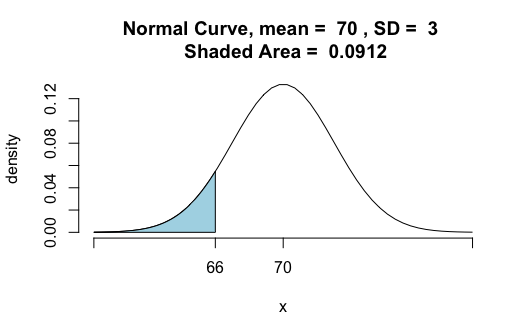

```
## [1] 0.09121122
```

```r
pnormGC(bound=66,region="below",
        mean=70,sd=3,graph=TRUE)
```

You should ask for a graph until you are confident of being able to use `pnormGC()` to get exactly the probability that you want.

# Find P(X > x)

For the same random variable $X \sim norm(70,3)$, suppose we want the probability that $X$ is greater than 69, i.e.:

$P(X > 69).$

Ask for:

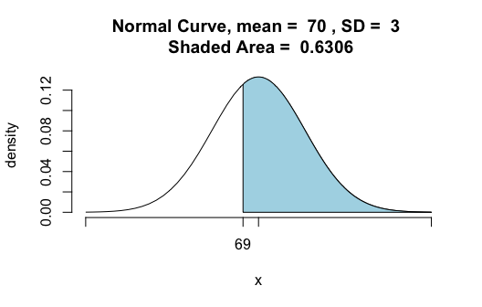

```
## [1] 0.6305587
```

```r
pnormGC(bound=69,region="above",
        mean=70,sd=3,graph=TRUE)
```

# Finding P(a < X < b)

For the same random variable $X \sim norm(70,3)$, suppose we want the probability that $X$ is between 68 and 72, i.e.:

$P(68 < X < 72).$

Ask for:

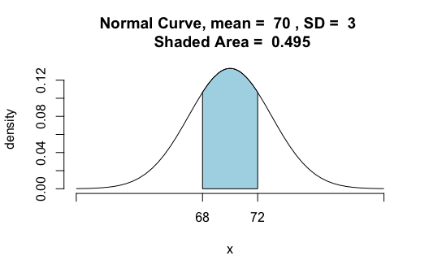

```
## [1] 0.4950149
```

```r
pnormGC(bound=c(68,72),region="between",
        mean=70,sd=3,graph=TRUE)
```

Observe that since there are two numbers—68 and 72—that are boundaries, we have to specify both of them for `pnormGC()` in the form of a list `c(68,72)`.

# “Outside” Probabilities

For the same random variable $X \sim norm(70,3)$, suppose we want the probability that either $X$ is less than 66 OR that $X$ is more than 73. Then we are looking for:

$P(X < 66 \textbf{ or } X > 73).$

We can find this with the command:

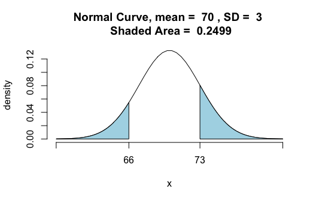

```
## [1] 0.2498665
```

```r
pnormGC(bound=c(66,73),region="outside",
         mean=70,sd=3,graph=TRUE)
```

# Non-Strict Inequalities

Suppose that for the same random variable $X \sim norm(70,3)$, you want the probability that $X$ will turn out to be *no more than* 66, i.e., you want:

$P(X \leq 66).$

You get this with exactly the same function call that gives you $P(X < 66)$, namely:

```r
pnormGC(bound=66,region="below",
        mean=70,sd=3)
```

Remember why? Normal random variables are *continuous* random variables, and for any continuous random variable the chance that it is *exactly* equal to any particular value is zero. For example, the probability that $X$ is exactly equal to 66 is given by:

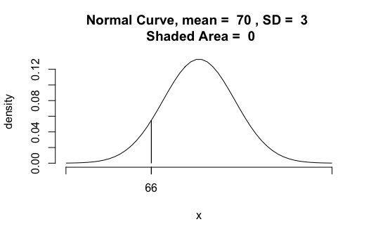

```
## [1] 0
```

```r
pnormGC(bound=c(66,66),region="between",
        mean=70,sd=3,graph=TRUE)
```

The probability of getting exactly 66 is given by the area of the line segment under the curve over 66. But the area of a line segment—if you think of it as a “rectangle”" with zero width—is zero!

When you ask for

$P(X \leq 66)$

as opposed to

$P(X < 66),$

you are adding on just the chance of $X$ being exactly 66. Since this extra chance is zero, you get the same probability as you did with the strict inequality.